# Project2_Darshan

#### Library

```r
library(dplyr)
```

```r
library(corrplot)
library(ggplot2)
library(plotly)
library(viridis)
library(hrbrthemes)
library(plotly)
library(ggcorrplot)
library(ggthemes)
library(ggpol)
library(scales)
library(ggbeeswarm)
library(ggridges)
```

### Dataset

```r
market_sales <- read.csv("Market_Sales.csv", header = TRUE)
market_sales
```

| Item_Identifier | Item_Weight | Branch | Customer.type | Gender | Item_Fat_Content | Item_Visibility | Item_Type | Item_MRP | Quantity | Outlet_Identifier | Outlet_Establishment_Year | Outlet_Size | Payment | Outlet_Location_Type | Outlet_Type | Item_Outlet_Sales | Rating |
| --- | --- | --- | --- | --- | --- | --- | --- | --- | --- | --- | --- | --- | --- | --- | --- | --- | --- |
| FDA15 | 9.300 | A | Member | Female | Low Fat | 0.016047301 | Dairy | 249.8092 | 7 | OUT049 | 1999 | Medium | Ewallet | Tier 1 | Supermarket Type1 | 3735.1380 | 9.1 |
| DRC01 | 5.920 | C | Normal | Female | Regular | 0.019278216 | Soft Drinks | 48.2692 | 5 | OUT018 | 2009 | Medium | Cash | Tier 3 | Supermarket Type2 | 443.4228 | 9.6 |
| FDN15 | 17.500 | A | Normal | Male | Low Fat | 0.016760075 | Meat | 141.6180 | 7 | OUT049 | 1999 | Medium | Credit card | Tier 1 | Supermarket Type1 | 2097.2700 | 7.4 |
| FDX07 | 19.200 | A | Member | Male | Regular | 0.000000000 | Fruits and Vegetables | 182.0950 | 8 | OUT010 | 1998 | High | Ewallet | Tier 3 | Grocery Store | 732.3800 | 8.4 |
| NCD19 | 8.930 | A | Normal | Male | Low Fat | 0.000000000 | Household | 53.8614 | 7 | OUT013 | 1987 | High | Ewallet | Tier 3 | Supermarket Type1 | 994.7052 | 5.3 |
| FDP36 | 10.395 | C | Normal | Male | Regular | 0.000000000 | Baking Goods | 51.4008 | 7 | OUT018 | 2009 | Medium | Ewallet | Tier 3 | Supermarket Type2 | 556.6088 | 4.1 |
| FDO10 | 13.650 | A | Member | Female | Regular | 0.012741089 | Snack Foods | 57.6588 | 6 | OUT013 | 1987 | High | Ewallet | Tier 3 | Supermarket Type1 | 343.5528 | 5.8 |
| FDP10 | 8.185 | C | Normal | Female | Low Fat | 0.127469857 | Snack Foods | 107.7622 | 10 | OUT027 | 1985 | Medium | Ewallet | Tier 3 | Supermarket Type3 | 4022.7636 | 8.0 |
| FDH17 | 18.200 | A | Member | Female | Regular | 0.016687114 | Frozen Foods | 96.9726 | 2 | OUT045 | 2002 | Medium | Credit card | Tier 2 | Supermarket Type1 | 1076.5986 | 7.2 |
| FDU28 | 19.250 | B | Member | Female | Regular | 0.094449590 | Frozen Foods | 187.8214 | 3 | OUT017 | 2007 | Small | Credit card | Tier 2 | Supermarket Type1 | 4710.5350 | 5.9 |

[output cut: 813 more lines]

## Darshan Siddhpura(0774684)

### => UniVariate Analysis - One Numeric Variable: Item_Weight.

### 1. Create an appropriate plot to visualize the distribution of this variable?

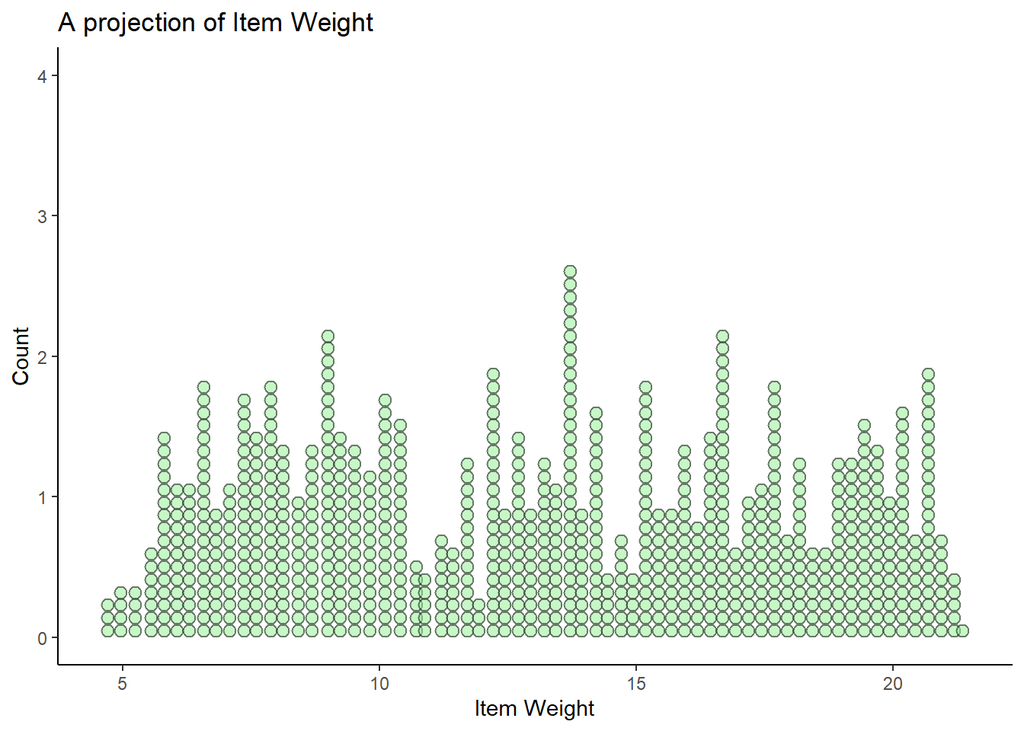

```r
a <- ggplot(market_sales, aes(x = Item_Weight))+
  geom_dotplot(aes(fill =Item_Weight),
               fill = "Light Green",alpha =0.5,
               binwidth = 1/4) +
  ylim(0,4)+
  labs(y = "Count",
       x = "Item Weight",
       title = "A projection of Item Weight") +
  theme_classic()

a
```

##### The Dot_plot displays projection of Item_weight.

#### 2.Consider any outliers present in the data.If present, specify the criteria used to identify them and provide a logical explanation for how you handled them ?

```r
mean(market_sales$Item_Weight)
```

```
## [1] 13.13443
```

```r
median(market_sales$Item_Weight)
```

```
## [1] 13.3
```

- > Answer : There are no outliers in the data, as mean and median values are approximately the same.

### 3.Describe the shape and skewness of the distribution ?

#### 4.Based on your answer to the previous question, decide if it is appropriate to apply a transformation to your data. If no, explain why not. If yes, name the transformation applied and visualize the transformed distribution

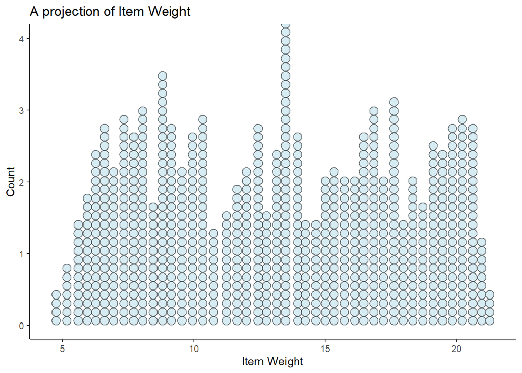

```r
a <- ggplot(market_sales, aes(x = Item_Weight))+
  geom_dotplot(aes(fill =Item_Weight),
               fill = "Light blue",alpha =0.5,
               binwidth = 1/3) +
  ylim(0,4)+
  labs(y = "Count",
       x = "Item Weight",
       title = "A projection of Item Weight") +
  theme_classic()

a
```

#### 5.Choose and calculate an appropriate measure of central tendency.

- > answer : We can either choose mean or median measure of central tendency as there are no outliers and the data is symmetric with uniform distribution.If the distribution is symmetric, center is often defined as the mean: mean ~ median

```r
Item_weight_mean <- mean(market_sales$Item_Weight)
Item_weight_mean
```

```
## [1] 13.13443
```

```r
Item_weight_medin <-median(market_sales$Item_Weight)
Item_weight_medin
```

```
## [1] 13.3
```

#### 6.Explain why you chose this as your measure of central tendency. Provide supporting evidence for your choice.

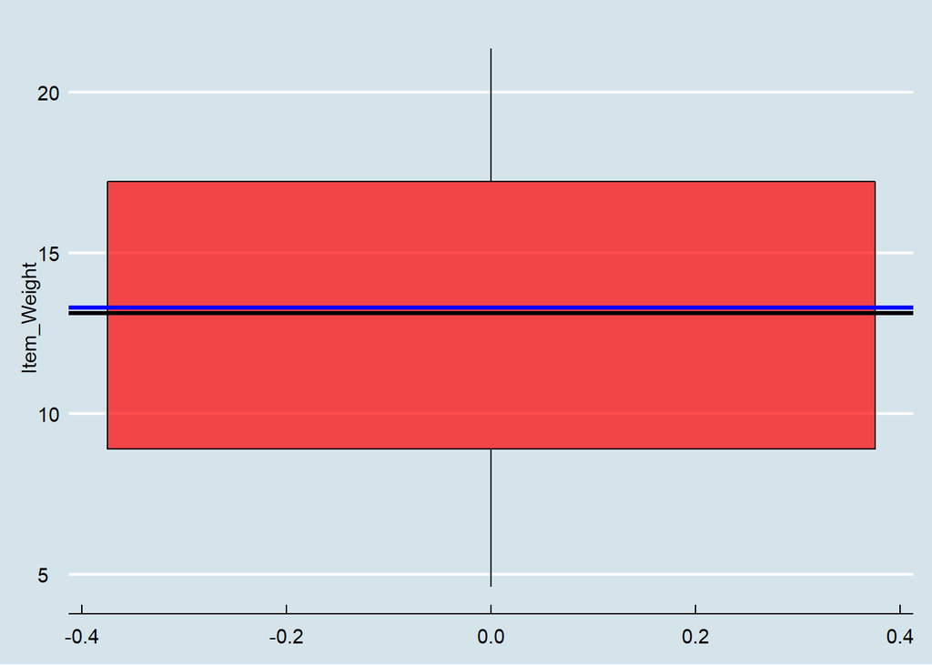

```r
ggplot(market_sales, aes(y = Item_Weight)) +
  geom_boxplot(fill = 'red', colour = 'black',alpha = 0.7) +
  geom_hline(yintercept = Item_weight_mean, colour = 'black',size = 1.2)+
  geom_hline(yintercept = Item_weight_medin, colour = 'blue',size = 1.2)+
  theme_economist()
```

#### 7.Choose and calculate a measure of spread that is appropriate for your chosen measure of central tendency. Explain why you chose this as your measure of spread The preferred measure of central tendency often depends on the shape of the distribution.

```r
Item_weight_mean
```

```
## [1] 13.13443
```

### => UniVariate Analysis - One Categorical Variable.

### For each categorical variable:

### 1.Create an appropriate plot to visualize the distribution of counts for this variable.

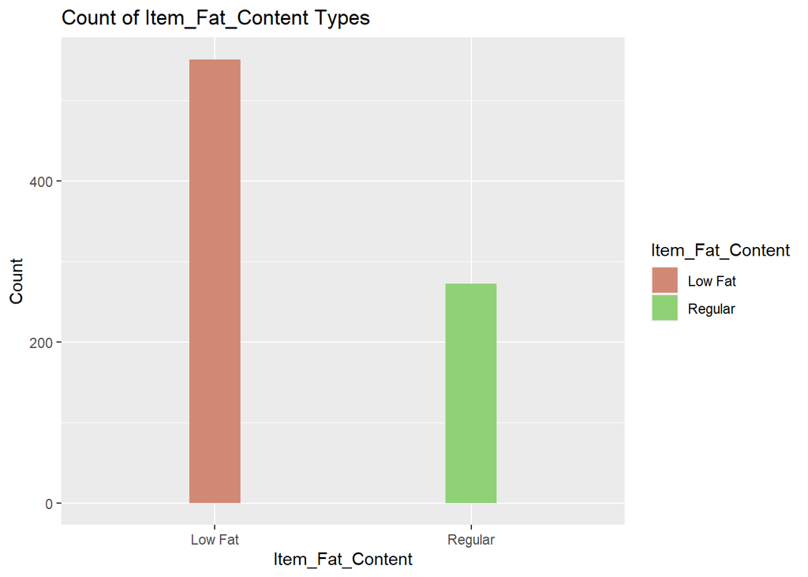

```r
ggplot(market_sales) +
  aes(x = Item_Fat_Content, fill = Item_Fat_Content) +
  geom_bar(width = 0.2) +
  hrbrthemes::scale_fill_ipsum() +
  labs(x = "Item_Fat_Content", y = "Count", title = "Count of Item_Fat_Content Types")
```

### 2.Create an appropriate plot to visualize the distribution of proportions for this variable.

[figure not shown]

```r
ggplot(market_sales) +
  aes(x = Item_Fat_Content,y = ..prop.., fill = Item_Fat_Content) +
  geom_bar(width = 0.2) +
  hrbrthemes::scale_fill_ipsum() +
  labs(x = "Item_Fat_Content", y = "Proportions", title = "Count of Item_Fat_Content Types")
```

### 3.Discuss any unusual observations for this variable?

```r
unusual_observations <- market_sales %>% group_by(`Item_Fat_Content`) %>% dplyr::summarise(n = n()) %>% mutate(prop=n/sum(n))
unusual_observations
```

|  | Item_Fat_Content | n | prop |
| --- | --- | --- | --- |
| 1 | Low Fat | 551 | 0.6695018 |
| 2 | Regular | 272 | 0.3304982 |

- > There are few unusual observations for this Item_fat_Content variable as seen above, unusual observation is for the Item_Fat_content(Low Fat 551 0.670) and ( Regular 272 0.330)

### 4. Discuss if there are too few/too many unique values?

```r
unique(market_sales$Item_Fat_Content)
```

```
## [1] "Low Fat" "Regular"
```

#### => BiVariate Analysis -Two Numeric Variables

### 1. Create an appropriate plot to visualize the relationship between the two variables.

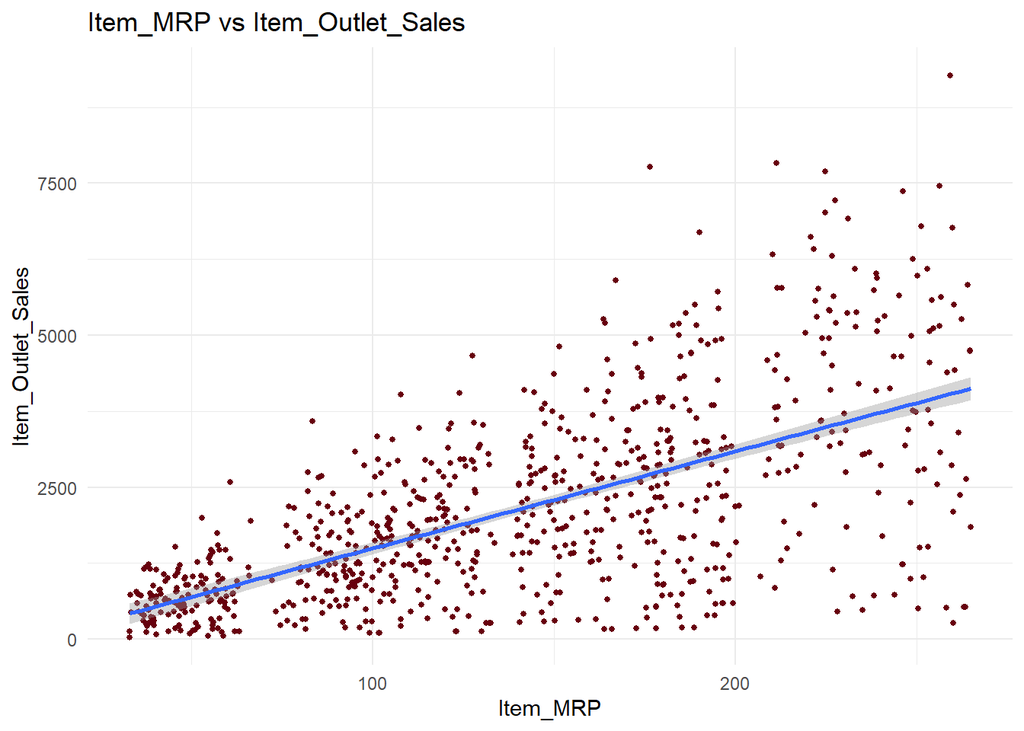

```r
ggplot(market_sales, aes(Item_MRP, Item_Outlet_Sales))+
  geom_jitter(size = 1L, colour = "#67000d") +
  geom_smooth(method = 'lm') +
  theme_minimal() +
  labs(y = "Item_Outlet_Sales",
       x = "Item_MRP",
       title = "Item_MRP vs Item_Outlet_Sales")
```

### 2. Describe the form, direction, and strength of the observed relationship. Include both qualitative and quantitative measures, as appropriate.

- > This plot shows a moderately strong, positive, linear association between Item_MRP and Item_Outlet_Sales.There don’t appear to be any outliers in the data.

### lets look at the Qualitative measure between Item_Outlet_Sales and Item_MRP.

```r
cor(market_sales$Item_Outlet_Sales,market_sales$Item_MRP)
```

```
## [1] 0.6263564
```

### 4 Describe the variability that you observe in the plot and how that corresponds to the strength you calculated in #2 above.

- > From the above visualization The variation in the Item_outlet_sales moderatelly increasing from less MRP to High MRP ,since the relationship is moderately positive and linear.

#### BiVariate Analysis - One Numeric and One Categorical Variable.

### 1. Create an appropriate plot to visualize the relationship between the two variables.

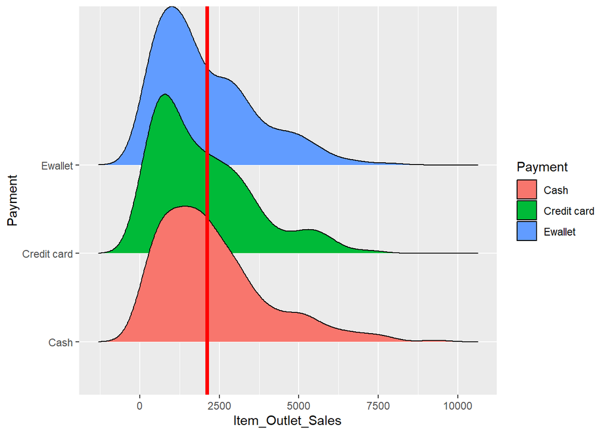

```r
ggplot(market_sales,aes(Item_Outlet_Sales,Payment))+
  geom_density_ridges(aes(fill = Payment))+
  geom_vline(xintercept = mean(market_sales$Item_Outlet_Sales), size = 1.5, color = "red")
```

### 2.Describe the form, direction, and strength of the observed relationship. Include both qualitative and quantitative measures, as appropriate.

- > There is no relationship between these two variables,Both are the independent,so we can not calculate quantities and measurements for any variables

### 3.Explain what this relationship means in the context of the data.

- > The Relationship to Identify if a growth of one variable has dependency on the other variable and in this case the payment of the item does not vary with an Outlet_sales. Hence, In the above context, the payments are independent of Outlet_sales.

### 4.Describe the variability that you observe in the plot and how that corresponds to the strength you calculated in #2 above

- > We cannot determine the variability with a covariance between the variables ‘Item_outlet-sales’ and ‘Payment’ as one variable is Numeric and the other is Categorical and these variables are independent of each other.